# NYPD Shooting Incident Data

Yasushi Yamanaka

2023-06-04

#### The data is a breakdown of every shooting incident in NYC from 2006 to 2022. It originates from <https://catalog.data.gov/dataset/nypd-shooting-incident-data-historic>. The following table is the brief description of columns contained in the file.

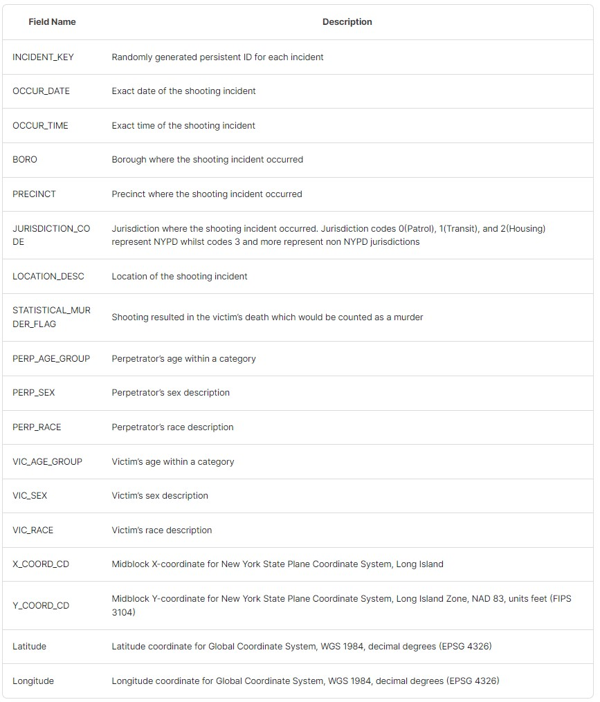

### Step 1 Importing CSV File

```r
library(tidyverse)
library(knitr)
file_name <- "https://data.cityofnewyork.us/api/views/833y-fsy8/rows.csv?accessType=DOWNLOAD"
shooting <- read_csv(file_name)
```

### Step 2 Tidying Data

1. Remove unnecessary columns.
2. Change **OCCUR_DATE** into date format.
3. Add new column **OCCUR_YEAR**, **OCCUR_YEAR_MONTH**, **OCCUR_MONTH** for later analysis.

```r
shooting <- shooting %>%
  select(cols=-c(LOC_OF_OCCUR_DESC, LOC_CLASSFCTN_DESC,
                 LOCATION_DESC, X_COORD_CD:Lon_Lat)) %>%
  mutate(OCCUR_DATE=mdy(OCCUR_DATE))
shooting <- shooting %>%
  mutate(OCCUR_YEAR=year(OCCUR_DATE), OCCUR_YEAR_MONTH=mdy(format(shooting$OCCUR_DATE,
                                                                  format="%m/01/%Y"))) %>%
  mutate(OCCUR_MONTH=month(OCCUR_DATE))
```

4. Change unkown values of **PERP_AGE_GROUP** to NA.

```r
kable(shooting %>% group_by(PERP_AGE_GROUP) %>% summarize(count=n()))
```

| PERP_AGE_GROUP | count |
| --- | --- |
| (null) | 640 |
| 1020 | 1 |
| 18-24 | 6222 |
| 224 | 1 |
| 25-44 | 5687 |
| 45-64 | 617 |
| 65+ | 60 |
| 940 | 1 |
| <18 | 1591 |
| UNKNOWN | 3148 |
| NA | 9344 |

```r
shooting$PERP_AGE_GROUP[shooting$PERP_AGE_GROUP=="(null)"] <- NA
shooting$PERP_AGE_GROUP[shooting$PERP_AGE_GROUP=="UNKNOWN"] <- NA
shooting$PERP_AGE_GROUP[shooting$PERP_AGE_GROUP=="1020"] <- NA
shooting$PERP_AGE_GROUP[shooting$PERP_AGE_GROUP=="224"] <- NA
shooting$PERP_AGE_GROUP[shooting$PERP_AGE_GROUP=="940"] <- NA
```

5. By the same way, we clear the unknown values in **PERP_SEX**, **PERP_RACE**, **VIC_AGE_GROUP**, **VIC_SEX**, **VIC_RACE**, **VIC_AGE_GROUP**.

```r
shooting$PERP_SEX[shooting$PERP_SEX == "(null)"] <- NA
shooting$PERP_SEX[shooting$PERP_SEX == "U"] <- NA
shooting$PERP_RACE[shooting$PERP_RACE == "(null)"] <- NA
shooting$PERP_RACE[shooting$PERP_RACE == "UNKNOWN"] <- NA
shooting$VIC_AGE_GROUP[shooting$VIC_AGE_GROUP=="1022"] <- NA
shooting$VIC_AGE_GROUP[shooting$VIC_AGE_GROUP=="UNKNOWN"] <- NA
shooting$VIC_SEX[shooting$VIC_SEX=="U"] <- NA
shooting$VIC_RACE[shooting$VIC_RACE=="UNKNOWN"] <- NA
```

6. Examine values in the remaining columns. Although columns **PERP_SEX**, **PERP_RACE**, and **PERP_AGE_GROUP** have large portion of NA values, we still keep them for further analysis.

```r
kable(data.frame(names(shooting),
                 unname(round(100*colSums(is.na(shooting))/length(shooting$INCIDENT_KEY), 2)))
      %>% `colnames<-`(c("Attributes", "NA%")))
```

| Attributes | NA% |
| --- | --- |
| INCIDENT_KEY | 0.00 |
| OCCUR_DATE | 0.00 |
| OCCUR_TIME | 0.00 |
| BORO | 0.00 |
| PRECINCT | 0.00 |
| JURISDICTION_CODE | 0.01 |
| STATISTICAL_MURDER_FLAG | 0.00 |
| PERP_AGE_GROUP | 48.09 |
| PERP_SEX | 41.92 |
| PERP_RACE | 43.15 |
| VIC_AGE_GROUP | 0.23 |
| VIC_SEX | 0.04 |
| VIC_RACE | 0.24 |
| OCCUR_YEAR | 0.00 |
| OCCUR_YEAR_MONTH | 0.00 |
| OCCUR_MONTH | 0.00 |

### Step 3 Data Analysis

1. Prepare data for analysis

```r
shooting_by_year <- shooting %>%
  group_by(OCCUR_YEAR) %>% summarise(INCIDENCE=n()) %>% ungroup()
shooting_by_year_month <- shooting %>%
  group_by(OCCUR_YEAR_MONTH) %>% summarise(INCIDENCE=n()) %>% ungroup()
shooting_by_month <- shooting %>%
  group_by(OCCUR_MONTH) %>% summarise(INCIDENCE=(n()/15)) %>% ungroup()
shooting_by_race <- shooting %>%
  group_by(PERP_RACE) %>% summarise(INCIDENCE=n()) %>% ungroup()
shooting_by_race$INCIDENCE <- shooting_by_race$INCIDENCE/sum(shooting_by_race$INCIDENCE)
```

2. Examine if shooting incidence has any long tern trend (yearly). We can observe that there is a declining trend from 2011 to 2019 and then a sharp increase in 2020.

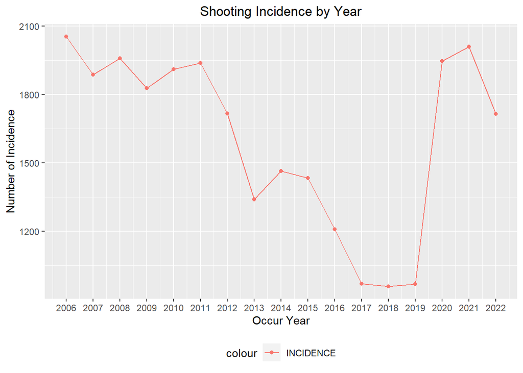

```r
ggplot(shooting_by_year, aes(x=OCCUR_YEAR, y=INCIDENCE)) +
  geom_line(aes(color="INCIDENCE")) + geom_point(aes(color="INCIDENCE")) +
  theme(legend.position="bottom", plot.title=element_text(hjust = 0.5)) +
  labs(title="Shooting Incidence by Year", y="Number of Incidence", x="Occur Year") +
  scale_x_continuous(breaks=seq(2006,2022,by=1))
```

3. We plot again the same graph but this time on a monthly basis. A seasonal trend can be obsered in this diagram.

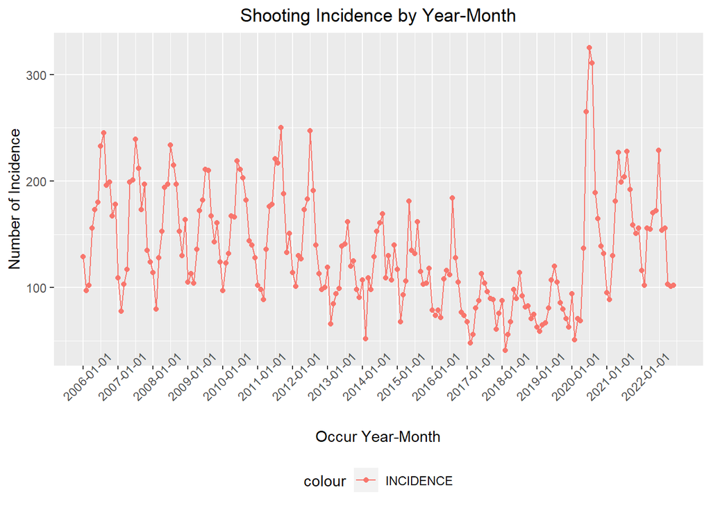

```r
ggplot(shooting_by_year_month, aes(x=OCCUR_YEAR_MONTH, y=INCIDENCE)) +
  geom_line(aes(color="INCIDENCE")) + geom_point(aes(color="INCIDENCE")) +
  theme(legend.position="bottom", axis.text.x=element_text(angle=45),
        plot.title=element_text(hjust = 0.5)) +
  labs(title="Shooting Incidence by Year-Month", y="Number of Incidence",
       x="Occur Year-Month") +
  scale_x_date(breaks=seq(as.Date("2006/01/01"), as.Date("2022/12/31"), "years"))
```

4. We average shooting incidences in all years on a monthly basis and the seasonal trend appears more clearly. (Peak at July and low at Feburary).

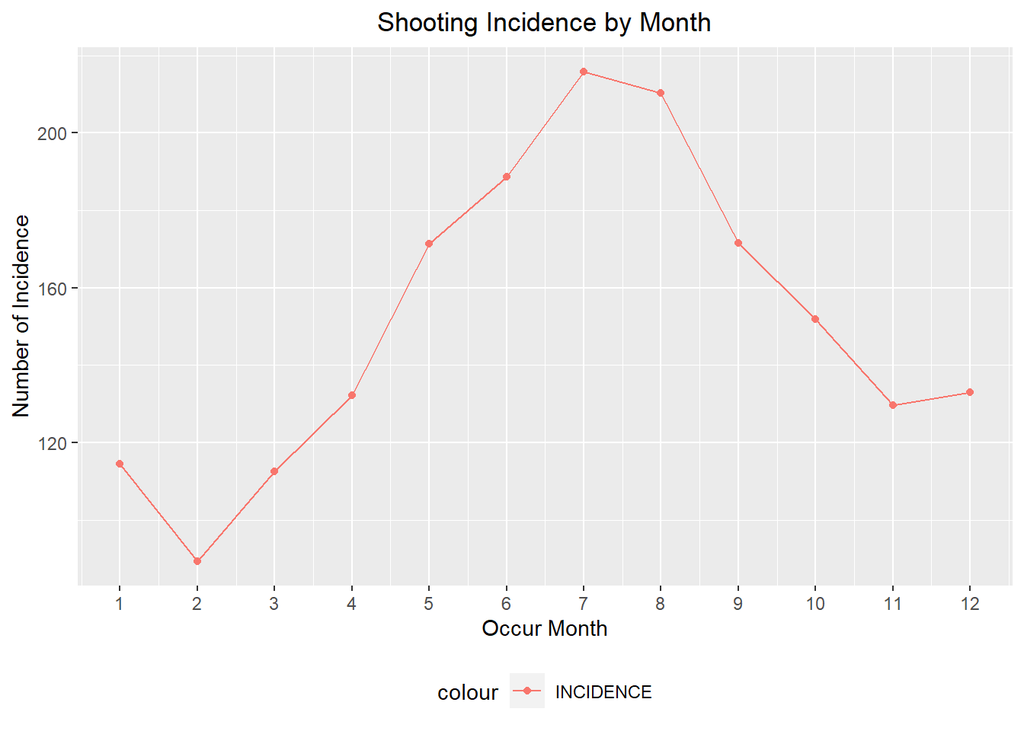

```r
ggplot(shooting_by_month, aes(x=OCCUR_MONTH, y=INCIDENCE)) +
  geom_line(aes(color="INCIDENCE")) + geom_point(aes(color="INCIDENCE")) +
  theme(legend.position="bottom", plot.title=element_text(hjust = 0.5)) +
  labs(title="Shooting Incidence by Month", y="Number of Incidence", x="Occur Month") +
  scale_x_continuous(breaks=seq(1,12,by=1))
```

5. Two questions araise from the previous analyses. The first one is why there are significant decrease and increase in different years? The second one is what contributes to the seasonal trend in shooting incidence?

### Step 4 Building Model

In here, we try to build a model to predict fatality of a shooting incidence. Logitic Regression is apply to the data with STATISTICAL_MURDER_FLAG as response variable and other variables as predictors. We first train the model with all columns (removing data with NA values).

```r
shooting_for_lg <- shooting %>% drop_na()
model <- glm(STATISTICAL_MURDER_FLAG ~., family=binomial(link='logit'),
             data=shooting_for_lg)
summary(model)
```

```
##
## Call:
## glm(formula = STATISTICAL_MURDER_FLAG ~ ., family = binomial(link = "logit"),
##     data = shooting_for_lg)
##
## Coefficients:
##                                     Estimate Std. Error z value Pr(>|z|)
## (Intercept)                        8.336e+03  2.240e+04   0.372  0.70976
## INCIDENT_KEY                       4.862e-09  2.603e-09   1.868  0.06181 .
## OCCUR_DATE                        -2.250e-03  2.264e-03  -0.994  0.32036
## OCCUR_TIME                        -4.537e-07  6.883e-07  -0.659  0.50980
## BOROBROOKLYN                      -2.132e-01  1.119e-01  -1.905  0.05675 .
## BOROMANHATTAN                     -1.799e-01  9.408e-02  -1.912  0.05586 .
## BOROQUEENS                        -2.308e-01  2.192e-01  -1.053  0.29239
## BOROSTATEN ISLAND                 -3.052e-01  2.762e-01  -1.105  0.26917
## PRECINCT                           9.292e-04  3.350e-03   0.277  0.78150
## JURISDICTION_CODE                 -9.301e-02  2.918e-02  -3.188  0.00143 **
## PERP_AGE_GROUP18-24                1.351e-01  7.380e-02   1.831  0.06715 .
## PERP_AGE_GROUP25-44                4.050e-01  7.524e-02   5.383 7.31e-08 ***
## PERP_AGE_GROUP45-64                7.126e-01  1.125e-01   6.334 2.39e-10 ***
## PERP_AGE_GROUP65+                  8.703e-01  2.831e-01   3.074  0.00211 **
## PERP_SEXM                         -1.539e-01  1.145e-01  -1.344  0.17887
## PERP_RACEASIAN / PACIFIC ISLANDER  1.200e+01  2.293e+02   0.052  0.95828
## PERP_RACEBLACK                     1.162e+01  2.293e+02   0.051  0.95957
## PERP_RACEBLACK HISPANIC            1.149e+01  2.293e+02   0.050  0.96003
## PERP_RACEWHITE                     1.220e+01  2.293e+02   0.053  0.95755
## PERP_RACEWHITE HISPANIC            1.169e+01  2.293e+02   0.051  0.95935
## VIC_AGE_GROUP18-24                 2.278e-01  7.686e-02   2.963  0.00305 **
## VIC_AGE_GROUP25-44                 3.150e-01  7.659e-02   4.113 3.91e-05 ***
## VIC_AGE_GROUP45-64                 3.201e-01  1.004e-01   3.188  0.00143 **
## VIC_AGE_GROUP65+                   4.938e-01  2.184e-01   2.261  0.02374 *
## VIC_SEXM                          -7.796e-02  6.282e-02  -1.241  0.21457
## VIC_RACEASIAN / PACIFIC ISLANDER   1.158e+01  1.864e+02   0.062  0.95049
## VIC_RACEBLACK                      1.143e+01  1.864e+02   0.061  0.95113
## VIC_RACEBLACK HISPANIC             1.124e+01  1.864e+02   0.060  0.95194
## VIC_RACEWHITE                      1.142e+01  1.864e+02   0.061  0.95113
## VIC_RACEWHITE HISPANIC             1.150e+01  1.864e+02   0.062  0.95080
## OCCUR_YEAR                        -4.242e+00  1.137e+01  -0.373  0.70901
## OCCUR_YEAR_MONTH                   1.366e-02  3.110e-02   0.439  0.66053
## OCCUR_MONTH                       -3.458e-01  9.478e-01  -0.365  0.71524
## ---
## Signif. codes:  0 '***' 0.001 '**' 0.01 '*' 0.05 '.' 0.1 ' ' 1
##
## (Dispersion parameter for binomial family taken to be 1)
##
##     Null deviance: 15318  on 13934  degrees of freedom
## Residual deviance: 15074  on 13902  degrees of freedom
## AIC: 15140
##
## Number of Fisher Scoring iterations: 11
```

```r
shooting_for_lg <- shooting %>%
  select(cols=-c(INCIDENT_KEY:OCCUR_DATE,JURISDICTION_CODE,OCCUR_YEAR,
                 OCCUR_MONTH,PRECINCT,OCCUR_YEAR_MONTH,VIC_SEX,PERP_SEX,
                 VIC_RACE,PERP_RACE,OCCUR_TIME)) %>% drop_na()
model <- glm(STATISTICAL_MURDER_FLAG ~., family=binomial(link='logit'),
             data=shooting_for_lg)
summary(model)
```

```
##
## Call:
## glm(formula = STATISTICAL_MURDER_FLAG ~ ., family = binomial(link = "logit"),
##     data = shooting_for_lg)
##
## Coefficients:
##                     Estimate Std. Error z value Pr(>|z|)
## (Intercept)         -1.58904    0.08816 -18.025  < 2e-16 ***
## BOROBROOKLYN        -0.18032    0.04873  -3.700 0.000215 ***
## BOROMANHATTAN       -0.21076    0.06360  -3.314 0.000921 ***
## BOROQUEENS          -0.13384    0.06222  -2.151 0.031467 *
## BOROSTATEN ISLAND   -0.15671    0.10560  -1.484 0.137793
## PERP_AGE_GROUP18-24  0.13431    0.07336   1.831 0.067109 .
## PERP_AGE_GROUP25-44  0.41921    0.07462   5.618 1.93e-08 ***
## PERP_AGE_GROUP45-64  0.79525    0.11045   7.200 6.03e-13 ***
## PERP_AGE_GROUP65+    1.01225    0.27519   3.678 0.000235 ***
## VIC_AGE_GROUP18-24   0.22666    0.07614   2.977 0.002910 **
## VIC_AGE_GROUP25-44   0.32013    0.07566   4.231 2.32e-05 ***
## VIC_AGE_GROUP45-64   0.34620    0.09914   3.492 0.000479 ***
## VIC_AGE_GROUP65+     0.59946    0.21356   2.807 0.005001 **
## ---
## Signif. codes:  0 '***' 0.001 '**' 0.01 '*' 0.05 '.' 0.1 ' ' 1
##
## (Dispersion parameter for binomial family taken to be 1)
##
##     Null deviance: 15460  on 14121  degrees of freedom
## Residual deviance: 15282  on 14109  degrees of freedom
## AIC: 15308
##
## Number of Fisher Scoring iterations: 4
```

Following is the prediction accurary for the trainig data. Not too bad for a first round try.

```r
mean((predict(model, newdate=shooting_for_lg,type="response") > 0.5) ==
       shooting_for_lg$STATISTICAL_MURDER_FLAG)
```

```
## [1] 0.7630647
```

### Step 5 Conclusion

- Number of shooting incidence has a decline trend from 2011 to 2019 and a sharp increase 2020. Further background research is needed for proper explanation.
- There is a monthly seasonal trend in the number of shooting incidence. This is an interesting question why such seasonality exists.
- Borough of the incidence, Age group of the perpetrators and victims can predict fatality of the shooting incidence in a certain degree.
- One of the biases in this study may occur in the perpetrator race. We can see in the following diagram that certain race contributes more than 40% of all shooting incidence. However, we can also observe that more 40% of the data are not properly maintained (values equal to NA or other unidentified values). Is it possible that the recording process contributes some bias to the data? Again, further research is needed to figure out this question.

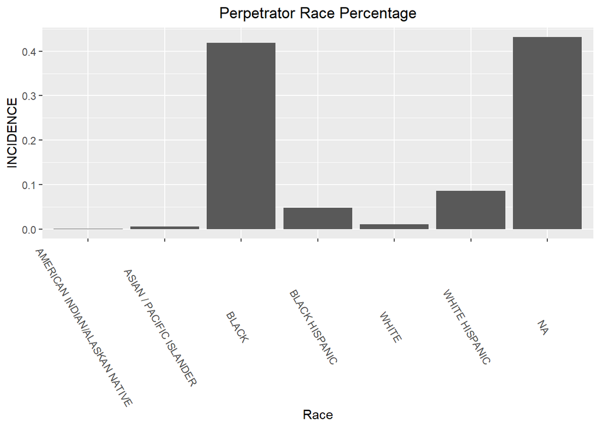

```r
ggplot(shooting_by_race, aes(x=PERP_RACE, y=INCIDENCE)) +
  geom_bar(stat="identity") +
  theme(plot.title=element_text(hjust = 0.5), axis.text.x=element_text(angle=-60)) +
  labs(title="Perpetrator Race Percentage", x="Race")
```